# README

**REQUIRED** — A **free** [Alpha Vantage](https://www.alphavantage.co/) API Key is required to use this module.

Follow the steps below to learn how to acquire an API Key and enter it into the Stock Price Tracker module.

## Steps to finish setup

- Register for an Alpha Vantage account
- Locate your API Key
- Enter your API Key in Infinity Dashboard

## What is an API key and why do I need it?

> An application programming interface key (API key) is a code passed in by computer programs calling an application programming interface (API) to identify the calling program, its developer, or its user to the Web site.

In order to access the stock prices using the Alpha Vantage API you will need to first register for an api key that will allow you access to their data. The API Key is free with lifetime access and Alpha Vantage does not send promotional or marketing materials to their users.

## Register for Alpha Vantage account

- Click the following link to open the [sign up page](https://www.alphavantage.co/support/#api-key)
- Fill out the form by entering your details
- Select **Other** in the ‘Which of the following best describes you?’ section.
- Click the `GET FREE API KEY` button to continue to the next section.

## Locating your API Key

After clicking the `GET FREE API KEY` a message will appear below the sign up form that says:

> Welcome to Alpha Vantage! Here is your API key: `<API_KEY>`. Please record this API key for lifetime access to Alpha Vantage.

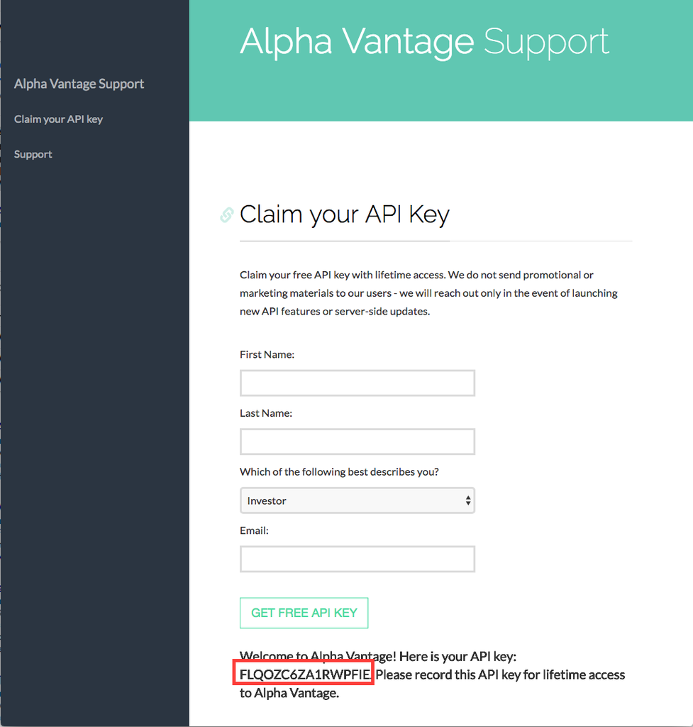

- Your API Key is listed after the `API key:` text and ends before the `.`
  - An Example Key is: `FLQOZC6ZA1RWPFIE`
- Select this text and copy it by performing a `Right Click` and selecting the `Copy` action.

## Entering your API Key into Infinity Dashboard

- Open Infinity Dashboard
- Click on the ‘Module Config’ item in the sidebar
- Locate the Stock Price Tracker module you want to configure
- Click the Pencil icon to open the module configuration
- Locate the **Alpha Vantage API Key** config option
- Click the **Click to edit this value** text field to edit the value.

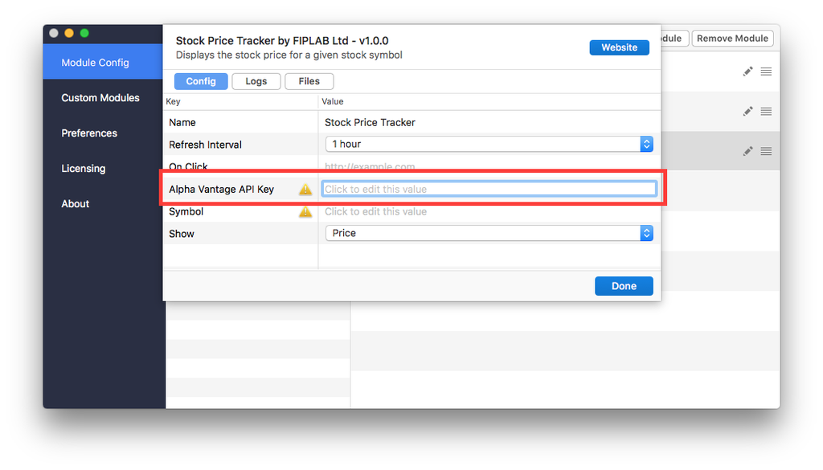

- Paste the copied API Key into the field by hitting `Command+V` or by `Right Clicking` the text field and selecting the `Paste` option.

**Tip** — You can reuse this API Key for multiple modules. You can `Right Click` the module in the list and select the `Duplicate` option to copy it and *ALL* of it’s configuration into a new module.

**Success** — You’re all set!